[figure not shown]

# Préparation CCF E5.2 : Supervision de salles

Ce système sera utilisé dans le cadre de l’épreuve de CCF E5.2.

## Présentation

Le système « Supervision de salles » permet un affichage de l’état de salles équipées de sonde ESP32-Weather.

Ce système est composé :

- de sondes ESP32-Weather communicant en WiFi ;
- d’un serveur Web Apache intégrant l’application PHP monitoring ;
- d’un réseau cablé Ethernet 100BASET ;
- d’un switch Ethernet et d’un routeur WiFi ;
- de postes clients Web (PC, tablette, …).

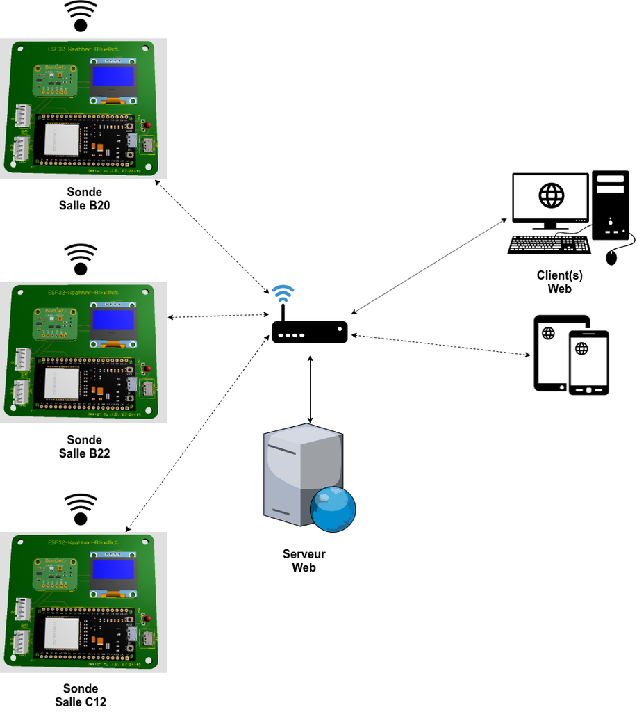

La sonde ESP32-Weather est une carte construite autour d’un ESP32 et équipée d’un capteur d’éclairement lumineux TSL 2591, d’un capteur DHT22 de température et d’humidité et d’une Led bicolore. Les mesures sont affichées périodiquement sur l’écran OLED de la carte.

Le carte embarque aussi un serveur TCP multi-clients via un réseau WiFi. Les clients connectés reçevront périodiquement les mesures de la sonde ainsi que l’état de la Led bicolore. Ils peuvent aussi envoyer une requête pour commander la Led.

La configuration du WiFi se fait par une interface Web :

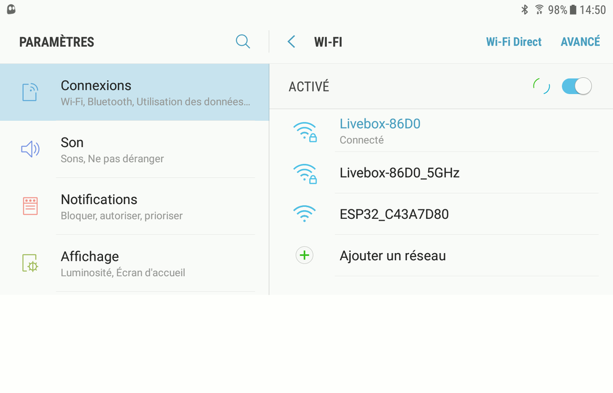

En utilisant un navigateur Web, on accède à l’application à partir de l’URL : Lien : [http://<serveur>/monitoring/](http://localhost/monitoring/).

On sélectionne la salle à superviser :

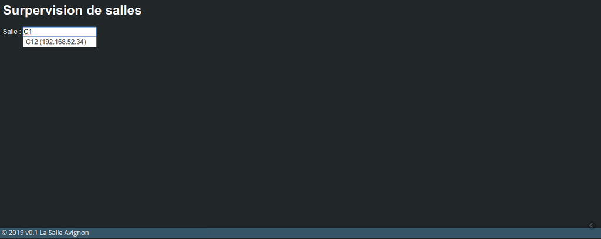

L’état de la salle est ensuite affichée dans le navigateur :

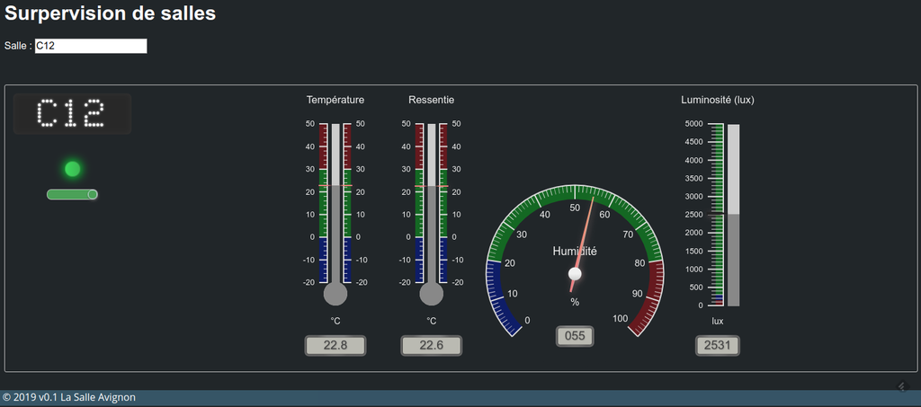

## Contraintes d’environnement

| Ressource | Version |
| --- | --- |
| OS | GNU Linux (Ubuntu 16.04 LTS minimum) |
| API | HTML5/CSS, jQuery, >= PHP 5 |

## Manuel d’installation sur le serveur (PC)

Télécharger et installer le paquet monitoring.deb :

```
$ wget -c http://tvaira.free.fr/bts-sn/activites/preparation-ccf-e52/installateurs/monitoring/monitoring.deb
$ sudo dpkg -i ./monitoring.deb

# Si besoin :
$ sudo apt -f install
```

Vérifications post-installation :

```
$ cd /var/www/html
$ ls -l
drwxrwxr-x 7 www-data   www-data  4096 oct.  25 13:51 monitoring

$ cd /var/www/html/monitoring
$ ls -l
drwxrwxr-x 2 www-data www-data 4,0K oct.  23 17:38 fonts/
drwxrwxr-x 2 www-data www-data 4,0K oct.  25 14:06 include/
-rw-r--r-- 1 www-data www-data  22K oct.  25 13:43 index.php
drwxr-xr-x 4 www-data www-data 4,0K oct.  24 18:21 jquery-ui/
drwxrwxr-x 2 www-data www-data 4,0K oct.  24 10:11 js/
-rw-r--r-- 1 www-data www-data  20K oct.  24 11:51 monitoring
-rw-r--r-- 1 www-data www-data    0 oct.  25 14:40 monitoring.log
-rw-r--r-- 1 www-data www-data 6,0K oct.  25 10:50 monitoring.php
-rw-r--r-- 1 www-data www-data 2,6K oct.  25 13:51 salles.php
drwxrwxr-x 2 www-data www-data 4,0K oct.  24 10:11 sql/

$ cat include/config.inc.php
...

$ apache2 -v
Server version: Apache/2.4.29 (Ubuntu)
Server built: 2019-08-26T13:41:23

$ systemctl status apache2
apache2.service - The Apache HTTP Server
   Loaded: loaded (/lib/systemd/system/apache2.service; enabled; vendor preset: enabled)
  Drop-In: /lib/systemd/system/apache2.service.d
           apache2-systemd.conf
   Active: active (running) since Thu 2019-10-24 09:09:02 CEST; 1 day 5h ago
 Main PID: 24291 (apache2)

$ systemctl status ufw

$ sudo ufw status verbose
État : inactif

$ sudo ufw app list
Applications disponibles :
  Apache
  Apache Full
  Apache Secure
```

Les paquets nécessaires sont :

```
$ sudo apt-get install apache2 libapache2-mod-php7.2
$ sudo apt-get install mysql-server php7.2-mysql
$ sudo apt-get install sqlite3 php7.2-sqlite3
```

L’application gère ses paramètres de configuration à partir d’un fichier `config.inc.php` :

```php
<?php

define("HOME_PATH", "/var/www/html/monitoring/");

$config['nom'] = 'MONITORING';
$config['description'] = 'Surpervision de salles';
$config['signature'] = '©&nbsp;2019&nbsp;v0.1&nbsp;La Salle Avignon';
$config['charset'] = 'utf-8';
$config['refresh'] = 10000; // en ms
$config['logfile'] = HOME_PATH."monitoring.log";
$config['bd'] = "array"; // Choix possible : "sqlite" ou "mysql" ou "array"
$config['dbname'] = "monitoring"; // pour "sqlite" ou "mysql"
$config['host'] = "localhost"; // seulement pour "mysql"
$config['username'] = "root"; // seulement pour "mysql"
$config['passwd'] = "password"; // seulement pour "mysql"

// Si $config['bd'] == "array"
$config['salles'] = array (
        0 => array('idSalle' => 1,'nom' => "B20",'description' => "salle BTS SN",'ip' => "192.168.52.30",'port' => 5000, 'etat' => 1),
        1 => array('idSalle' => 2,'nom' => "B22",'description' => "salle BTS SN",'ip' => "192.168.52.31",'port' => 5000,'etat' => 1),
        2 => array('idSalle' => 3,'nom' => "C12",'description' => "salle",'ip' => "192.168.52.34",'port' => 5000,'etat' => 1)
);

?>
```

Le fichier `config.inc.php` est stocké dans `/var/www/html/monotoring/include`.

Pour désinstaller le paquet, il suffit de faire :

```
$ sudo dpkg -P monitoring
```

## Serveurs Apache et MySQL

Une tâche *cron* archive les *logs* d’une semaine chaque dimanche à 23h59.

## Manuel d’utilisation

Utiliser un client web (navigateur) et accéder au site web du système Supervision de salles.

## Diagnostic

```
$ sudo tail -f /var/www/html/monotoring/monitoring.log
```

Il est possible d’effectuer des tests de communications avec les sondes installées : [http://<serveur>/monitoring/maintenance.php](http://localhost/monitoring/maintenance.php)

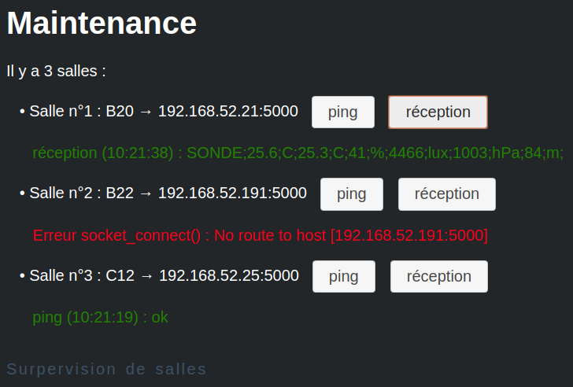

## Activités

- Matériels : esp32-weather
- Serveurs : [Serveur Ubuntu](http://tvaira.free.fr/bts-sn/admin/tp-installation-serveur.pdf), [Serveur Web](http://tvaira.free.fr/bts-sn/admin/tp-installation-http.pdf), [Serveur Base de données](http://tvaira.free.fr/bts-sn/admin/tp-installation-mysql.pdf)
- Autre(s) : Base de données Supervision de salles, [Parefeu](http://tvaira.free.fr/bts-sn/admin/tp-installation-parefeu.pdf), [Utilisateurs](http://tvaira.free.fr/bts-sn/admin/tp-installation-utilisateurs.pdf), [Processus](http://tvaira.free.fr/bts-sn/admin/tp-installation-processus.pdf)

Retour au sommaire